```python
import pandas as pd
import numpy as np
import matplotlib.pyplot as plt
import seaborn as sns

from sklearn.model_selection import train_test_split
from sklearn.cluster import KMeans

pd.set_option('display.max_columns', None)
pd.set_option('display.max_rows', 100)
import warnings
warnings.filterwarnings("ignore")
```

# Data overview

I wanted to find something that the students could easily relate to without being too overwhelming. I have attached a file with about 33K records from an online book seller. All of the F *variables are count, e.g., Fclassic3 is the number of classics books the customer has bought in the past. The M* variables are monetary, so Mclassic3 is the amount spent on classics in the past. There is also recency (r), overall frequency (F), overall monetary (m) and time on file in days (tof).

# Read in Data

```python
ecom = pd.read_excel("Final Assignment - Week 9.xlsx").drop(columns = ['Unnamed: 66','Unnamed: 67','Dear Greg,'])
ecom.head()
```

|  | id | logtarg | r | f | m | tof | Ffiction1 | Fclassics3 | Fcartoons5 | Flegends6 | Fphilosophy7 | Freligion8 | Fpsychology9 | Flinguistics10 | Fart12 | Fmusic14 | Ffacsimile17 | Fhistory19 | Fconthist20 | Feconomy21 | Fpolitics22 | Fscience23 | Fcompsci26 | Frailroads27 | Fmaps30 | Ftravelguides31 | Fhealth35 | Fcooking36 | Flearning37 | … |
| --- | --- | --- | --- | --- | --- | --- | --- | --- | --- | --- | --- | --- | --- | --- | --- | --- | --- | --- | --- | --- | --- | --- | --- | --- | --- | --- | --- | --- | --- | --- |
| 0 | 914 | NaN | 194 | 7 | 318.894775 | 1703 | 1 | 0 | 1 | 0 | 0 | 0 | 0 | 0 | 1 | 7 | 0 | 0 | 17 | 0 | 0 | 0 | 0 | 0 | 0 | 2 | 2 | 1 | 0 | … |
| 1 | 957 | NaN | 3 | 14 | 368.052246 | 2364 | 1 | 0 | 2 | 0 | 0 | 0 | 0 | 0 | 0 | 4 | 0 | 4 | 4 | 0 | 0 | 0 | 1 | 0 | 0 | 0 | 7 | 0 | 4 | … |
| 2 | 1406 | NaN | 1489 | 15 | 423.298340 | 2371 | 0 | 0 | 0 | 0 | 0 | 0 | 0 | 0 | 0 | 0 | 0 | 1 | 34 | 0 | 0 | 0 | 0 | 0 | 0 | 0 | 0 | 0 | 0 | … |
| 3 | 1414 | NaN | 155 | 4 | 71.217041 | 1290 | 0 | 0 | 0 | 0 | 0 | 0 | 0 | 0 | 0 | 0 | 0 | 0 | 7 | 0 | 0 | 0 | 0 | 0 | 0 | 0 | 0 | 0 | 0 | … |
| 4 | 1546 | NaN | 194 | 6 | 442.638184 | 2188 | 0 | 0 | 1 | 0 | 3 | 1 | 0 | 1 | 1 | 3 | 0 | 6 | 7 | 1 | 0 | 2 | 0 | 2 | 0 | 1 | 3 | 0 | 2 | … |

# EDA

### 1. Perform descriptive statistics on all variables to help understand the data, the distributions and basic info you have to work with on this challenge. (Mean, Standard Deviation, Median, Min, Max and Histogram)

```python
ecom.dtypes
```

```
id                    int64
logtarg             float64
r                     int64
f                     int64
m                   float64
tof                   int64
Ffiction1             int64
Fclassics3            int64
Fcartoons5            int64
Flegends6             int64
Fphilosophy7          int64
Freligion8            int64
Fpsychology9          int64
Flinguistics10        int64
Fart12                int64
Fmusic14              int64
Ffacsimile17          int64
Fhistory19            int64
Fconthist20           int64
Feconomy21            int64
Fpolitics22           int64
Fscience23            int64
Fcompsci26            int64
Frailroads27          int64
Fmaps30               int64
Ftravelguides31       int64
Fhealth35             int64
Fcooking36            int64
Flearning37           int64
FGamesRiddles38       int64
Fsports39             int64
Fhobby40              int64
Fnature41             int64
Fencyclopaedia44      int64
Fvideos50             int64
Fnonbooks99           int64
Mfiction1           float64
Mclassics3          float64
Mcartoons5          float64
Mlegends6           float64
```

[output cut: 12 more lines]

```
Mcompsci26          float64
Mrailroads27        float64
Mmaps30             float64
Mtravelguides31     float64
Mhealth35           float64
Mcooking36          float64
Mlearning37         float64
MGamesRiddles38     float64
Msports39           float64
Mhobby40            float64
Mnature41           float64
Mencyclopaedia44    float64
Mvideos50           float64
Mnonbooks99         float64
dtype: object
```

```python
ecom.describe()
#33713 records
# r = recency, smaller number is most recent
# f = frequency, higher number is more shopped
# m = monetary, more $ spent
# tof = time on file, higher number is longer customer

# F_ are count variables
# M_ are amount in $$

# what is logtarg (Log of target var??)

## Each row is an individual customer
```

|  | id | logtarg | r | f | m | tof | Ffiction1 | Fclassics3 | Fcartoons5 | Flegends6 | Fphilosophy7 | Freligion8 | Fpsychology9 | Flinguistics10 | Fart12 | Fmusic14 | Ffacsimile17 | Fhistory19 | Fconthist20 | Feconomy21 | Fpolitics22 | Fscience23 | Fcompsci26 | Frailroads27 | Fmaps30 | Ftravelguides31 | Fhealth35 | Fcooking36 | Flearning37 | … |
| --- | --- | --- | --- | --- | --- | --- | --- | --- | --- | --- | --- | --- | --- | --- | --- | --- | --- | --- | --- | --- | --- | --- | --- | --- | --- | --- | --- | --- | --- | --- |
| count | 3.371300e+04 | 8311.000000 | 33713.000000 | 33713.000000 | 33713.000000 | 33713.000000 | 33713.000000 | 33713.000000 | 33713.000000 | 33713.000000 | 33713.000000 | 33713.000000 | 33713.000000 | 33713.000000 | 33713.000000 | 33713.000000 | 33713.000000 | 33713.000000 | 33713.000000 | 33713.000000 | 33713.000000 | 33713.000000 | 33713.000000 | 33713.000000 | 33713.000000 | 33713.000000 | 33713.000000 | 33713.000000 | 33713.00000 | … |
| mean | 8.234209e+06 | 0.130050 | 508.427254 | 5.820603 | 251.924325 | 1296.088186 | 0.590900 | 0.228102 | 0.356480 | 0.104767 | 0.290659 | 0.980957 | 0.046570 | 0.203215 | 0.608549 | 2.320974 | 0.050960 | 2.647940 | 2.153947 | 0.208377 | 0.029959 | 0.410791 | 0.150862 | 0.187020 | 0.074986 | 1.484976 | 2.109898 | 0.425444 | 0.61718 | … |
| std | 4.426015e+06 | 0.659962 | 542.440039 | 7.008049 | 3929.929826 | 818.976321 | 1.762201 | 0.865510 | 1.105653 | 0.527764 | 1.088606 | 3.112212 | 0.262156 | 0.641489 | 1.884077 | 6.681362 | 0.398608 | 5.930653 | 5.989002 | 0.755520 | 0.190992 | 1.480713 | 0.596788 | 0.974306 | 0.335845 | 4.368954 | 5.340294 | 1.695695 | 1.64184 | … |
| min | 9.140000e+02 | 0.000000 | 0.000000 | 0.000000 | 0.000000 | 0.000000 | 0.000000 | 0.000000 | 0.000000 | 0.000000 | 0.000000 | 0.000000 | 0.000000 | 0.000000 | 0.000000 | 0.000000 | 0.000000 | 0.000000 | 0.000000 | 0.000000 | 0.000000 | 0.000000 | 0.000000 | 0.000000 | 0.000000 | 0.000000 | 0.000000 | 0.000000 | 0.00000 | … |
| 25% | 4.391616e+06 | 0.000000 | 117.000000 | 1.000000 | 39.899994 | 536.000000 | 0.000000 | 0.000000 | 0.000000 | 0.000000 | 0.000000 | 0.000000 | 0.000000 | 0.000000 | 0.000000 | 0.000000 | 0.000000 | 0.000000 | 0.000000 | 0.000000 | 0.000000 | 0.000000 | 0.000000 | 0.000000 | 0.000000 | 0.000000 | 0.000000 | 0.000000 | 0.00000 | … |
| 50% | 7.967691e+06 | 0.000000 | 293.000000 | 3.000000 | 102.629944 | 1311.000000 | 0.000000 | 0.000000 | 0.000000 | 0.000000 | 0.000000 | 0.000000 | 0.000000 | 0.000000 | 0.000000 | 0.000000 | 0.000000 | 1.000000 | 0.000000 | 0.000000 | 0.000000 | 0.000000 | 0.000000 | 0.000000 | 0.000000 | 0.000000 | 0.000000 | 0.000000 | 0.00000 | … |
| 75% | 1.199823e+07 | 0.000000 | 712.000000 | 7.000000 | 247.297485 | 2132.000000 | 1.000000 | 0.000000 | 0.000000 | 0.000000 | 0.000000 | 1.000000 | 0.000000 | 0.000000 | 1.000000 | 2.000000 | 0.000000 | 3.000000 | 2.000000 | 0.000000 | 0.000000 | 0.000000 | 0.000000 | 0.000000 | 0.000000 | 1.000000 | 2.000000 | 0.000000 | 1.00000 | … |
| max | 1.625264e+07 | 6.082878 | 2460.000000 | 118.000000 | 532892.000000 | 2462.000000 | 109.000000 | 29.000000 | 49.000000 | 22.000000 | 35.000000 | 134.000000 | 8.000000 | 21.000000 | 113.000000 | 264.000000 | 23.000000 | 192.000000 | 213.000000 | 18.000000 | 6.000000 | 55.000000 | 17.000000 | 61.000000 | 10.000000 | 164.000000 | 210.000000 | 78.000000 | 59.00000 | … |

```python
ecom['targ'] = 10**(ecom['logtarg'])
ecom.head()
```

|  | id | logtarg | r | f | m | tof | Ffiction1 | Fclassics3 | Fcartoons5 | Flegends6 | Fphilosophy7 | Freligion8 | Fpsychology9 | Flinguistics10 | Fart12 | Fmusic14 | Ffacsimile17 | Fhistory19 | Fconthist20 | Feconomy21 | Fpolitics22 | Fscience23 | Fcompsci26 | Frailroads27 | Fmaps30 | Ftravelguides31 | Fhealth35 | Fcooking36 | Flearning37 | … |
| --- | --- | --- | --- | --- | --- | --- | --- | --- | --- | --- | --- | --- | --- | --- | --- | --- | --- | --- | --- | --- | --- | --- | --- | --- | --- | --- | --- | --- | --- | --- |
| 0 | 914 | NaN | 194 | 7 | 318.894775 | 1703 | 1 | 0 | 1 | 0 | 0 | 0 | 0 | 0 | 1 | 7 | 0 | 0 | 17 | 0 | 0 | 0 | 0 | 0 | 0 | 2 | 2 | 1 | 0 | … |
| 1 | 957 | NaN | 3 | 14 | 368.052246 | 2364 | 1 | 0 | 2 | 0 | 0 | 0 | 0 | 0 | 0 | 4 | 0 | 4 | 4 | 0 | 0 | 0 | 1 | 0 | 0 | 0 | 7 | 0 | 4 | … |
| 2 | 1406 | NaN | 1489 | 15 | 423.298340 | 2371 | 0 | 0 | 0 | 0 | 0 | 0 | 0 | 0 | 0 | 0 | 0 | 1 | 34 | 0 | 0 | 0 | 0 | 0 | 0 | 0 | 0 | 0 | 0 | … |
| 3 | 1414 | NaN | 155 | 4 | 71.217041 | 1290 | 0 | 0 | 0 | 0 | 0 | 0 | 0 | 0 | 0 | 0 | 0 | 0 | 7 | 0 | 0 | 0 | 0 | 0 | 0 | 0 | 0 | 0 | 0 | … |
| 4 | 1546 | NaN | 194 | 6 | 442.638184 | 2188 | 0 | 0 | 1 | 0 | 3 | 1 | 0 | 1 | 1 | 3 | 0 | 6 | 7 | 1 | 0 | 2 | 0 | 2 | 0 | 1 | 3 | 0 | 2 | … |

```python
ecom.isnull().sum()
# logtarg, 25402 are null. majority
```

```
id                      0
logtarg             25402
r                       0
f                       0
m                       0
tof                     0
Ffiction1               0
Fclassics3              0
Fcartoons5              0
Flegends6               0
Fphilosophy7            0
Freligion8              0
Fpsychology9            0
Flinguistics10          0
Fart12                  0
Fmusic14                0
Ffacsimile17            0
Fhistory19              0
Fconthist20             0
Feconomy21              0
Fpolitics22             0
Fscience23              0
Fcompsci26              0
Frailroads27            0
Fmaps30                 0
Ftravelguides31         0
Fhealth35               0
Fcooking36              0
Flearning37             0
FGamesRiddles38         0
Fsports39               0
Fhobby40                0
Fnature41               0
Fencyclopaedia44        0
Fvideos50               0
Fnonbooks99             0
Mfiction1               0
Mclassics3              0
Mcartoons5              0
Mlegends6               0
```

[output cut: 12 more lines]

```
Mcompsci26              0
Mrailroads27            0
Mmaps30                 0
Mtravelguides31         0
Mhealth35               0
Mcooking36              0
Mlearning37             0
MGamesRiddles38         0
Msports39               0
Mhobby40                0
Mnature41               0
Mencyclopaedia44        0
Mvideos50               0
Mnonbooks99             0
dtype: int64
```

```
array([[<AxesSubplot:title={'center':'id'}>,
        <AxesSubplot:title={'center':'logtarg'}>,
        <AxesSubplot:title={'center':'r'}>,
        <AxesSubplot:title={'center':'f'}>,
        <AxesSubplot:title={'center':'m'}>,
        <AxesSubplot:title={'center':'tof'}>,
        <AxesSubplot:title={'center':'Ffiction1'}>,
        <AxesSubplot:title={'center':'Fclassics3'}>],
       [<AxesSubplot:title={'center':'Fcartoons5'}>,
        <AxesSubplot:title={'center':'Flegends6'}>,
        <AxesSubplot:title={'center':'Fphilosophy7'}>,
        <AxesSubplot:title={'center':'Freligion8'}>,
        <AxesSubplot:title={'center':'Fpsychology9'}>,
        <AxesSubplot:title={'center':'Flinguistics10'}>,
        <AxesSubplot:title={'center':'Fart12'}>,
        <AxesSubplot:title={'center':'Fmusic14'}>],
       [<AxesSubplot:title={'center':'Ffacsimile17'}>,
        <AxesSubplot:title={'center':'Fhistory19'}>,
        <AxesSubplot:title={'center':'Fconthist20'}>,
        <AxesSubplot:title={'center':'Feconomy21'}>,
        <AxesSubplot:title={'center':'Fpolitics22'}>,
        <AxesSubplot:title={'center':'Fscience23'}>,
        <AxesSubplot:title={'center':'Fcompsci26'}>,
        <AxesSubplot:title={'center':'Frailroads27'}>],
       [<AxesSubplot:title={'center':'Fmaps30'}>,
        <AxesSubplot:title={'center':'Ftravelguides31'}>,
        <AxesSubplot:title={'center':'Fhealth35'}>,
        <AxesSubplot:title={'center':'Fcooking36'}>,
        <AxesSubplot:title={'center':'Flearning37'}>,
        <AxesSubplot:title={'center':'FGamesRiddles38'}>,
        <AxesSubplot:title={'center':'Fsports39'}>,
        <AxesSubplot:title={'center':'Fhobby40'}>],
       [<AxesSubplot:title={'center':'Fnature41'}>,
        <AxesSubplot:title={'center':'Fencyclopaedia44'}>,
        <AxesSubplot:title={'center':'Fvideos50'}>,
        <AxesSubplot:title={'center':'Fnonbooks99'}>,
        <AxesSubplot:title={'center':'Mfiction1'}>,
        <AxesSubplot:title={'center':'Mclassics3'}>,
        <AxesSubplot:title={'center':'Mcartoons5'}>,
        <AxesSubplot:title={'center':'Mlegends6'}>],
```

[output cut: 13 more lines]

```
        <AxesSubplot:title={'center':'Mrailroads27'}>,
        <AxesSubplot:title={'center':'Mmaps30'}>,
        <AxesSubplot:title={'center':'Mtravelguides31'}>],
       [<AxesSubplot:title={'center':'Mhealth35'}>,
        <AxesSubplot:title={'center':'Mcooking36'}>,
        <AxesSubplot:title={'center':'Mlearning37'}>,
        <AxesSubplot:title={'center':'MGamesRiddles38'}>,
        <AxesSubplot:title={'center':'Msports39'}>,
        <AxesSubplot:title={'center':'Mhobby40'}>,
        <AxesSubplot:title={'center':'Mnature41'}>,
        <AxesSubplot:title={'center':'Mencyclopaedia44'}>],
       [<AxesSubplot:title={'center':'Mvideos50'}>,
        <AxesSubplot:title={'center':'Mnonbooks99'}>, <AxesSubplot:>,
        <AxesSubplot:>, <AxesSubplot:>, <AxesSubplot:>, <AxesSubplot:>,
        <AxesSubplot:>]], dtype=object)
```

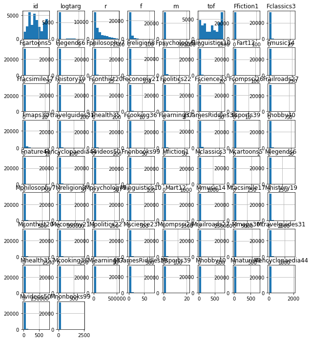

```python
ecom.hist(figsize=(10,12))
```

```
array([[<AxesSubplot:title={'center':'r'}>,
        <AxesSubplot:title={'center':'f'}>],
       [<AxesSubplot:title={'center':'m'}>,
        <AxesSubplot:title={'center':'tof'}>]], dtype=object)
```

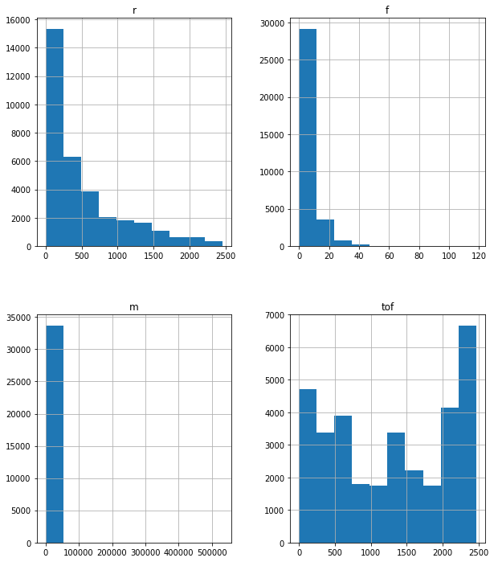

```python
ecom[['r','f','m','tof']].hist(figsize=(10,12))
```

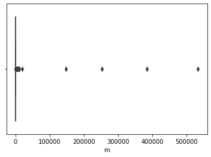

```python
sns.boxplot(x=ecom['m'])
```

```
array([[<AxesSubplot:title={'center':'Ffiction1'}>,
        <AxesSubplot:title={'center':'Fclassics3'}>,
        <AxesSubplot:title={'center':'Fcartoons5'}>,
        <AxesSubplot:title={'center':'Flegends6'}>,
        <AxesSubplot:title={'center':'Fphilosophy7'}>],
       [<AxesSubplot:title={'center':'Freligion8'}>,
        <AxesSubplot:title={'center':'Fpsychology9'}>,
        <AxesSubplot:title={'center':'Flinguistics10'}>,
        <AxesSubplot:title={'center':'Fart12'}>,
        <AxesSubplot:title={'center':'Fmusic14'}>],
       [<AxesSubplot:title={'center':'Ffacsimile17'}>,
        <AxesSubplot:title={'center':'Fhistory19'}>,
        <AxesSubplot:title={'center':'Fconthist20'}>,
        <AxesSubplot:title={'center':'Feconomy21'}>,
        <AxesSubplot:title={'center':'Fpolitics22'}>],
       [<AxesSubplot:title={'center':'Fscience23'}>,
        <AxesSubplot:title={'center':'Fcompsci26'}>,
        <AxesSubplot:title={'center':'Frailroads27'}>,
        <AxesSubplot:title={'center':'Fmaps30'}>,
        <AxesSubplot:title={'center':'Ftravelguides31'}>],
       [<AxesSubplot:title={'center':'Fhealth35'}>,
        <AxesSubplot:title={'center':'Fcooking36'}>,
        <AxesSubplot:title={'center':'Flearning37'}>,
        <AxesSubplot:title={'center':'FGamesRiddles38'}>,
        <AxesSubplot:title={'center':'Fsports39'}>],
       [<AxesSubplot:title={'center':'Fhobby40'}>,
        <AxesSubplot:title={'center':'Fnature41'}>,
        <AxesSubplot:title={'center':'Fencyclopaedia44'}>,
        <AxesSubplot:title={'center':'Fvideos50'}>,
        <AxesSubplot:title={'center':'Fnonbooks99'}>]], dtype=object)
```

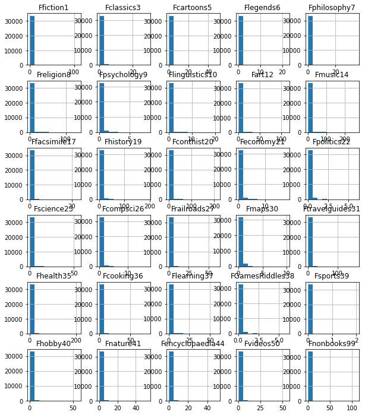

```python
f_cols = [col for col in ecom if col.startswith('F')]
ecom[f_cols].hist(figsize=(10,12))
```

```
array([[<AxesSubplot:title={'center':'Mfiction1'}>,
        <AxesSubplot:title={'center':'Mclassics3'}>,
        <AxesSubplot:title={'center':'Mcartoons5'}>,
        <AxesSubplot:title={'center':'Mlegends6'}>,
        <AxesSubplot:title={'center':'Mphilosophy7'}>],
       [<AxesSubplot:title={'center':'Mreligion8'}>,
        <AxesSubplot:title={'center':'Mpsychology9'}>,
        <AxesSubplot:title={'center':'Mlinguistics10'}>,
        <AxesSubplot:title={'center':'Mart12'}>,
        <AxesSubplot:title={'center':'Mmusic14'}>],
       [<AxesSubplot:title={'center':'Mfacsimile17'}>,
        <AxesSubplot:title={'center':'Mhistory19'}>,
        <AxesSubplot:title={'center':'Mconthist20'}>,
        <AxesSubplot:title={'center':'Meconomy21'}>,
        <AxesSubplot:title={'center':'Mpolitics22'}>],
       [<AxesSubplot:title={'center':'Mscience23'}>,
        <AxesSubplot:title={'center':'Mcompsci26'}>,
        <AxesSubplot:title={'center':'Mrailroads27'}>,
        <AxesSubplot:title={'center':'Mmaps30'}>,
        <AxesSubplot:title={'center':'Mtravelguides31'}>],
       [<AxesSubplot:title={'center':'Mhealth35'}>,
        <AxesSubplot:title={'center':'Mcooking36'}>,
        <AxesSubplot:title={'center':'Mlearning37'}>,
        <AxesSubplot:title={'center':'MGamesRiddles38'}>,
        <AxesSubplot:title={'center':'Msports39'}>],
       [<AxesSubplot:title={'center':'Mhobby40'}>,
        <AxesSubplot:title={'center':'Mnature41'}>,
        <AxesSubplot:title={'center':'Mencyclopaedia44'}>,
        <AxesSubplot:title={'center':'Mvideos50'}>,
        <AxesSubplot:title={'center':'Mnonbooks99'}>]], dtype=object)
```

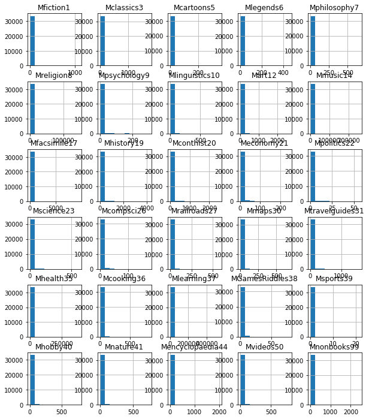

```python
m_cols = [col for col in ecom if col.startswith('M')]
ecom[m_cols].hist(figsize=(10,12))
```

### 2. Create a new data set with more descriptive labels and the data needed for analysis

```python
## Remove outliers
def remove_outliers(df, columns):
    int_df = df
    for x in int_df[columns]:
        int_df = int_df[int_df[x] < df[x].quantile(0.99)]
    return int_df
```

```python
# features = ecom.drop(columns = ['id', 'logtarg', 'targ']).columns
# features
```

[output not shown]

```python
ecom2 = remove_outliers(ecom, ['r','f','m'])
ecom2.head()
```

|  | id | logtarg | r | f | m | tof | Ffiction1 | Fclassics3 | Fcartoons5 | Flegends6 | Fphilosophy7 | Freligion8 | Fpsychology9 | Flinguistics10 | Fart12 | Fmusic14 | Ffacsimile17 | Fhistory19 | Fconthist20 | Feconomy21 | Fpolitics22 | Fscience23 | Fcompsci26 | Frailroads27 | Fmaps30 | Ftravelguides31 | Fhealth35 | Fcooking36 | Flearning37 | … |
| --- | --- | --- | --- | --- | --- | --- | --- | --- | --- | --- | --- | --- | --- | --- | --- | --- | --- | --- | --- | --- | --- | --- | --- | --- | --- | --- | --- | --- | --- | --- |
| 0 | 914 | NaN | 194 | 7 | 318.894775 | 1703 | 1 | 0 | 1 | 0 | 0 | 0 | 0 | 0 | 1 | 7 | 0 | 0 | 17 | 0 | 0 | 0 | 0 | 0 | 0 | 2 | 2 | 1 | 0 | … |
| 1 | 957 | NaN | 3 | 14 | 368.052246 | 2364 | 1 | 0 | 2 | 0 | 0 | 0 | 0 | 0 | 0 | 4 | 0 | 4 | 4 | 0 | 0 | 0 | 1 | 0 | 0 | 0 | 7 | 0 | 4 | … |
| 2 | 1406 | NaN | 1489 | 15 | 423.298340 | 2371 | 0 | 0 | 0 | 0 | 0 | 0 | 0 | 0 | 0 | 0 | 0 | 1 | 34 | 0 | 0 | 0 | 0 | 0 | 0 | 0 | 0 | 0 | 0 | … |
| 3 | 1414 | NaN | 155 | 4 | 71.217041 | 1290 | 0 | 0 | 0 | 0 | 0 | 0 | 0 | 0 | 0 | 0 | 0 | 0 | 7 | 0 | 0 | 0 | 0 | 0 | 0 | 0 | 0 | 0 | 0 | … |
| 4 | 1546 | NaN | 194 | 6 | 442.638184 | 2188 | 0 | 0 | 1 | 0 | 3 | 1 | 0 | 1 | 1 | 3 | 0 | 6 | 7 | 1 | 0 | 2 | 0 | 2 | 0 | 1 | 3 | 0 | 2 | … |

```python
ecom2.head()
```

|  | id | logtarg | r | f | m | tof | Ffiction1 | Fclassics3 | Fcartoons5 | Flegends6 | Fphilosophy7 | Freligion8 | Fpsychology9 | Flinguistics10 | Fart12 | Fmusic14 | Ffacsimile17 | Fhistory19 | Fconthist20 | Feconomy21 | Fpolitics22 | Fscience23 | Fcompsci26 | Frailroads27 | Fmaps30 | Ftravelguides31 | Fhealth35 | Fcooking36 | Flearning37 | … |
| --- | --- | --- | --- | --- | --- | --- | --- | --- | --- | --- | --- | --- | --- | --- | --- | --- | --- | --- | --- | --- | --- | --- | --- | --- | --- | --- | --- | --- | --- | --- |
| 0 | 914 | NaN | 194 | 7 | 318.894775 | 1703 | 1 | 0 | 1 | 0 | 0 | 0 | 0 | 0 | 1 | 7 | 0 | 0 | 17 | 0 | 0 | 0 | 0 | 0 | 0 | 2 | 2 | 1 | 0 | … |
| 1 | 957 | NaN | 3 | 14 | 368.052246 | 2364 | 1 | 0 | 2 | 0 | 0 | 0 | 0 | 0 | 0 | 4 | 0 | 4 | 4 | 0 | 0 | 0 | 1 | 0 | 0 | 0 | 7 | 0 | 4 | … |
| 2 | 1406 | NaN | 1489 | 15 | 423.298340 | 2371 | 0 | 0 | 0 | 0 | 0 | 0 | 0 | 0 | 0 | 0 | 0 | 1 | 34 | 0 | 0 | 0 | 0 | 0 | 0 | 0 | 0 | 0 | 0 | … |
| 3 | 1414 | NaN | 155 | 4 | 71.217041 | 1290 | 0 | 0 | 0 | 0 | 0 | 0 | 0 | 0 | 0 | 0 | 0 | 0 | 7 | 0 | 0 | 0 | 0 | 0 | 0 | 0 | 0 | 0 | 0 | … |
| 4 | 1546 | NaN | 194 | 6 | 442.638184 | 2188 | 0 | 0 | 1 | 0 | 3 | 1 | 0 | 1 | 1 | 3 | 0 | 6 | 7 | 1 | 0 | 2 | 0 | 2 | 0 | 1 | 3 | 0 | 2 | … |

```python
print(len(ecom2))
print(len(ecom))
```

```
32831
33713
```

```python
ecom2 = ecom2.drop(columns = ['logtarg', 'targ']).rename(columns={"r": "Recency", "f": "Frequency", "m" : "Monetary", "tof" : "Time on File"})
ecom2.head()
```

|  | id | Recency | Frequency | Monetary | Time on File | Ffiction1 | Fclassics3 | Fcartoons5 | Flegends6 | Fphilosophy7 | Freligion8 | Fpsychology9 | Flinguistics10 | Fart12 | Fmusic14 | Ffacsimile17 | Fhistory19 | Fconthist20 | Feconomy21 | Fpolitics22 | Fscience23 | Fcompsci26 | Frailroads27 | Fmaps30 | Ftravelguides31 | Fhealth35 | Fcooking36 | Flearning37 | FGamesRiddles38 | … |
| --- | --- | --- | --- | --- | --- | --- | --- | --- | --- | --- | --- | --- | --- | --- | --- | --- | --- | --- | --- | --- | --- | --- | --- | --- | --- | --- | --- | --- | --- | --- |
| 0 | 914 | 194 | 7 | 318.894775 | 1703 | 1 | 0 | 1 | 0 | 0 | 0 | 0 | 0 | 1 | 7 | 0 | 0 | 17 | 0 | 0 | 0 | 0 | 0 | 0 | 2 | 2 | 1 | 0 | 0 | … |
| 1 | 957 | 3 | 14 | 368.052246 | 2364 | 1 | 0 | 2 | 0 | 0 | 0 | 0 | 0 | 0 | 4 | 0 | 4 | 4 | 0 | 0 | 0 | 1 | 0 | 0 | 0 | 7 | 0 | 4 | 0 | … |
| 2 | 1406 | 1489 | 15 | 423.298340 | 2371 | 0 | 0 | 0 | 0 | 0 | 0 | 0 | 0 | 0 | 0 | 0 | 1 | 34 | 0 | 0 | 0 | 0 | 0 | 0 | 0 | 0 | 0 | 0 | 0 | … |
| 3 | 1414 | 155 | 4 | 71.217041 | 1290 | 0 | 0 | 0 | 0 | 0 | 0 | 0 | 0 | 0 | 0 | 0 | 0 | 7 | 0 | 0 | 0 | 0 | 0 | 0 | 0 | 0 | 0 | 0 | 0 | … |
| 4 | 1546 | 194 | 6 | 442.638184 | 2188 | 0 | 0 | 1 | 0 | 3 | 1 | 0 | 1 | 1 | 3 | 0 | 6 | 7 | 1 | 0 | 2 | 0 | 2 | 0 | 1 | 3 | 0 | 2 | 0 | … |

```python
# ecom2.columns = ecom2.columns.str.replace(r'\d+', '')
# ecom2.head()
```

```python
f_cols2 = ecom2[f_cols].columns.str.replace("F", "Count_")
m_cols2 = ecom2[m_cols].columns.str.replace("M", "Sales_")
f_cols2
```

```
Index(['Count_fiction1', 'Count_classics3', 'Count_cartoons5',
       'Count_legends6', 'Count_philosophy7', 'Count_religion8',
       'Count_psychology9', 'Count_linguistics10', 'Count_art12',
       'Count_music14', 'Count_facsimile17', 'Count_history19',
       'Count_conthist20', 'Count_economy21', 'Count_politics22',
       'Count_science23', 'Count_compsci26', 'Count_railroads27',
       'Count_maps30', 'Count_travelguides31', 'Count_health35',
       'Count_cooking36', 'Count_learning37', 'Count_GamesRiddles38',
       'Count_sports39', 'Count_hobby40', 'Count_nature41',
       'Count_encyclopaedia44', 'Count_videos50', 'Count_nonbooks99'],
      dtype='object')
```

```python
ecom2.columns
```

```
Index(['id', 'Recency', 'Frequency', 'Monetary', 'Time on File', 'Ffiction1',
       'Fclassics3', 'Fcartoons5', 'Flegends6', 'Fphilosophy7', 'Freligion8',
       'Fpsychology9', 'Flinguistics10', 'Fart12', 'Fmusic14', 'Ffacsimile17',
       'Fhistory19', 'Fconthist20', 'Feconomy21', 'Fpolitics22', 'Fscience23',
       'Fcompsci26', 'Frailroads27', 'Fmaps30', 'Ftravelguides31', 'Fhealth35',
       'Fcooking36', 'Flearning37', 'FGamesRiddles38', 'Fsports39', 'Fhobby40',
       'Fnature41', 'Fencyclopaedia44', 'Fvideos50', 'Fnonbooks99',
       'Mfiction1', 'Mclassics3', 'Mcartoons5', 'Mlegends6', 'Mphilosophy7',
       'Mreligion8', 'Mpsychology9', 'Mlinguistics10', 'Mart12', 'Mmusic14',
       'Mfacsimile17', 'Mhistory19', 'Mconthist20', 'Meconomy21',
       'Mpolitics22', 'Mscience23', 'Mcompsci26', 'Mrailroads27', 'Mmaps30',
       'Mtravelguides31', 'Mhealth35', 'Mcooking36', 'Mlearning37',
       'MGamesRiddles38', 'Msports39', 'Mhobby40', 'Mnature41',
       'Mencyclopaedia44', 'Mvideos50', 'Mnonbooks99'],
      dtype='object')
```

```python
new_cols = ['id', 'Recency', 'Frequency', 'Monetary', 'Time on File'] + f_cols2.tolist() + m_cols2.tolist()
ecom2.columns = new_cols
```

```python
ecom2.columns = ecom2.columns.str.replace(r'\d+', '')
```

```python
ecom2.head()
```

|  | id | Recency | Frequency | Monetary | Time on File | Count_fiction | Count_classics | Count_cartoons | Count_legends | Count_philosophy | Count_religion | Count_psychology | Count_linguistics | Count_art | Count_music | Count_facsimile | Count_history | Count_conthist | Count_economy | Count_politics | Count_science | Count_compsci | Count_railroads | Count_maps | Count_travelguides | Count_health | Count_cooking | Count_learning | Count_GamesRiddles | … |
| --- | --- | --- | --- | --- | --- | --- | --- | --- | --- | --- | --- | --- | --- | --- | --- | --- | --- | --- | --- | --- | --- | --- | --- | --- | --- | --- | --- | --- | --- | --- |
| 0 | 914 | 194 | 7 | 318.894775 | 1703 | 1 | 0 | 1 | 0 | 0 | 0 | 0 | 0 | 1 | 7 | 0 | 0 | 17 | 0 | 0 | 0 | 0 | 0 | 0 | 2 | 2 | 1 | 0 | 0 | … |
| 1 | 957 | 3 | 14 | 368.052246 | 2364 | 1 | 0 | 2 | 0 | 0 | 0 | 0 | 0 | 0 | 4 | 0 | 4 | 4 | 0 | 0 | 0 | 1 | 0 | 0 | 0 | 7 | 0 | 4 | 0 | … |
| 2 | 1406 | 1489 | 15 | 423.298340 | 2371 | 0 | 0 | 0 | 0 | 0 | 0 | 0 | 0 | 0 | 0 | 0 | 1 | 34 | 0 | 0 | 0 | 0 | 0 | 0 | 0 | 0 | 0 | 0 | 0 | … |
| 3 | 1414 | 155 | 4 | 71.217041 | 1290 | 0 | 0 | 0 | 0 | 0 | 0 | 0 | 0 | 0 | 0 | 0 | 0 | 7 | 0 | 0 | 0 | 0 | 0 | 0 | 0 | 0 | 0 | 0 | 0 | … |
| 4 | 1546 | 194 | 6 | 442.638184 | 2188 | 0 | 0 | 1 | 0 | 3 | 1 | 0 | 1 | 1 | 3 | 0 | 6 | 7 | 1 | 0 | 2 | 0 | 2 | 0 | 1 | 3 | 0 | 2 | 0 | … |

```python
ecom2.isnull().sum()
```

```
id                     0
Recency                0
Frequency              0
Monetary               0
Time on File           0
Count_fiction          0
Count_classics         0
Count_cartoons         0
Count_legends          0
Count_philosophy       0
Count_religion         0
Count_psychology       0
Count_linguistics      0
Count_art              0
Count_music            0
Count_facsimile        0
Count_history          0
Count_conthist         0
Count_economy          0
Count_politics         0
Count_science          0
Count_compsci          0
Count_railroads        0
Count_maps             0
Count_travelguides     0
Count_health           0
Count_cooking          0
Count_learning         0
Count_GamesRiddles     0
Count_sports           0
Count_hobby            0
Count_nature           0
Count_encyclopaedia    0
Count_videos           0
Count_nonbooks         0
Sales_fiction          0
Sales_classics         0
Sales_cartoons         0
Sales_legends          0
Sales_philosophy       0
```

[output cut: 11 more lines]

```
Sales_compsci          0
Sales_railroads        0
Sales_maps             0
Sales_travelguides     0
Sales_health           0
Sales_cooking          0
Sales_learning         0
Sales_GamesRiddles     0
Sales_sports           0
Sales_hobby            0
Sales_nature           0
Sales_encyclopaedia    0
Sales_videos           0
Sales_nonbooks         0
dtype: int64
```

### 3. Document the problem you will address using the SMART framework – use hypothetical data and goals for the improvement your Recommendation Engine will deliver

The consulting team’s approach to increase the volume of total books sold for the ecommerce website is to build a clustering model that will result in an explainable identification methodology to target customers with specific campaigns and increase customer satisfaction via data-driven strategic decisions.

### 4. Select from a pool of titles and roles within the company to create a core team (Maximum 6-8 members) to perform the analysis and develop the pitch to your CMO.

(Pool: VP Finance, Data Engineer, SVP Data Scientist, Financial Analyst, Customer Satisfaction Manager, Website Analyst, Webmaster, VP Marketing, Performance Marketing SEM/SEO Analyst, Customer Retention Manager, Marketing Manager, Customer Research Analyst, Data Visualization Specialist, Sr. Data Scientist, Marketing Analytics Manager, IT Manager for Ecommerce Data Storage, Marketing Messaging/Creative Designer, Ecommerce Financial Manager)

The following roles would be a part of the core team:

1. Customer Satisfaction Manager: To bring some background into how the ecom website knows whether or not the customer is satisfied
2. Marketing Manager: To compare the proposed strategy to the current one
3. Sr. Data Scientist: To develop a new model for recommendation
4. Data Engineer: To eventually implement the model to be used in production
5. SVP Data Scientist: To represent the data science team and bring any more ideas to the table
6. Customer Research Analyst: Similar to Customer Satisfaction Manager, to bring additional details to customer behavior and what may be relevant

### 5. Describe the team strengths and discipline focus areas that justify your need for each person and why this talent will be necessary for your success. This justification is intended to both motivate the team members and gain support from their managers to join your team.

This was described in the previous question, but generally the people who are part of this core team are to bring more life to how the proposed model can benefit the ecom website and enhance their marketing.

### 6. Choose either a “supervised” or an “unsupervised” approach to segment/cluster current customers using the data provided.

You may develop a rules base algorithm to ID a customer on each new transaction and assign them to one of your segments/clusters. Create sample data (5-10 records) with synthetic data to show how a new transaction will be scored and assigned to a segment/cluster. (You can use RFM<Recency, Frequency, Monetary Value>, K-Means or other rules based approached. Your segmentation must be MECE (Mutually Exclusive, Comprehensively Exhaustive) and any record of any incoming customer must receive one score and become assigned to a single segment – even if the transaction is incomplete or abandoned prior to purchase.

```python
df = ecom2.drop(columns = 'id')
df.head()
```

|  | Recency | Frequency | Monetary | Time on File | Count_fiction | Count_classics | Count_cartoons | Count_legends | Count_philosophy | Count_religion | Count_psychology | Count_linguistics | Count_art | Count_music | Count_facsimile | Count_history | Count_conthist | Count_economy | Count_politics | Count_science | Count_compsci | Count_railroads | Count_maps | Count_travelguides | Count_health | Count_cooking | Count_learning | Count_GamesRiddles | Count_sports | … |
| --- | --- | --- | --- | --- | --- | --- | --- | --- | --- | --- | --- | --- | --- | --- | --- | --- | --- | --- | --- | --- | --- | --- | --- | --- | --- | --- | --- | --- | --- | --- |
| 0 | 194 | 7 | 318.894775 | 1703 | 1 | 0 | 1 | 0 | 0 | 0 | 0 | 0 | 1 | 7 | 0 | 0 | 17 | 0 | 0 | 0 | 0 | 0 | 0 | 2 | 2 | 1 | 0 | 0 | 0 | … |
| 1 | 3 | 14 | 368.052246 | 2364 | 1 | 0 | 2 | 0 | 0 | 0 | 0 | 0 | 0 | 4 | 0 | 4 | 4 | 0 | 0 | 0 | 1 | 0 | 0 | 0 | 7 | 0 | 4 | 0 | 0 | … |
| 2 | 1489 | 15 | 423.298340 | 2371 | 0 | 0 | 0 | 0 | 0 | 0 | 0 | 0 | 0 | 0 | 0 | 1 | 34 | 0 | 0 | 0 | 0 | 0 | 0 | 0 | 0 | 0 | 0 | 0 | 0 | … |
| 3 | 155 | 4 | 71.217041 | 1290 | 0 | 0 | 0 | 0 | 0 | 0 | 0 | 0 | 0 | 0 | 0 | 0 | 7 | 0 | 0 | 0 | 0 | 0 | 0 | 0 | 0 | 0 | 0 | 0 | 0 | … |
| 4 | 194 | 6 | 442.638184 | 2188 | 0 | 0 | 1 | 0 | 3 | 1 | 0 | 1 | 1 | 3 | 0 | 6 | 7 | 1 | 0 | 2 | 0 | 2 | 0 | 1 | 3 | 0 | 2 | 0 | 0 | … |

```python
train, test = train_test_split(df, test_size=0.3, random_state=123)
```

```python
## Kmeans clustering

distortions = []
K = range(1,5)
for k in K:
    kmeanModel = KMeans(n_clusters=k)
    kmeanModel.fit(train)
    distortions.append(kmeanModel.inertia_)
```

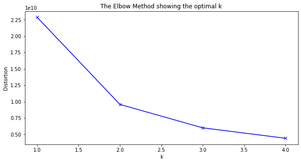

```python
plt.figure(figsize=(10,5))
plt.plot(K, distortions, 'bx-')
plt.xlabel('k')
plt.ylabel('Distortion')
plt.title('The Elbow Method showing the optimal k')
plt.show()
```

```python
### 3 seems like a good number of clusters
```

```python
kmeanModel = KMeans(n_clusters=3)
kmeanModel.fit(train)
```

```
KMeans(n_clusters=3)
```

```python
train_Y_kmeans = kmeanModel.fit_predict(train)
```

```python
set(train_Y_kmeans)
```

```
{0, 1, 2}
```

```python
train_Y_kmeans
```

```
array([1, 2, 0, ..., 0, 2, 0], dtype=int32)
```

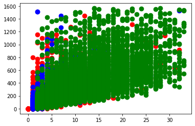

```python
plt.scatter(train[train_Y_kmeans == 0]["Frequency"], train[train_Y_kmeans == 0]["Monetary"], s = 75, c = 'red')
plt.scatter(train[train_Y_kmeans == 1]["Frequency"], train[train_Y_kmeans == 1]["Monetary"], s = 75, c = 'blue')
plt.scatter(train[train_Y_kmeans == 2]["Frequency"], train[train_Y_kmeans == 2]["Monetary"], s = 75, c = 'green')
```

```python
test_Y_kmeans = kmeanModel.predict(test)
```

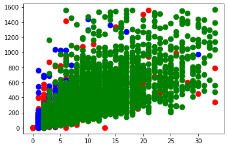

```python
plt.scatter(test[test_Y_kmeans == 0]["Frequency"], test[test_Y_kmeans == 0]["Monetary"], s = 75, c = 'red')
plt.scatter(test[test_Y_kmeans == 1]["Frequency"], test[test_Y_kmeans == 1]["Monetary"], s = 75, c = 'blue')
plt.scatter(test[test_Y_kmeans == 2]["Frequency"], test[test_Y_kmeans == 2]["Monetary"], s = 75, c = 'green')
```

```python
# plt.scatter(train[train_Y_kmeans == 0]["Count_fiction"], train[train_Y_kmeans == 0]["Monetary"], s = 75, c = 'red')
# plt.scatter(train[train_Y_kmeans == 1]["Count_fiction"], train[train_Y_kmeans == 1]["Monetary"], s = 75, c = 'blue')
# plt.scatter(train[train_Y_kmeans == 2]["Count_fiction"], train[train_Y_kmeans == 2]["Monetary"], s = 75, c = 'green')
```

```python
# Mean of all variables
train['clusters'] = train_Y_kmeans
train.groupby("clusters").mean()
```

| clusters | Recency | Frequency | Monetary | Time on File | Count_fiction | Count_classics | Count_cartoons | Count_legends | Count_philosophy | Count_religion | Count_psychology | Count_linguistics | Count_art | Count_music | Count_facsimile | Count_history | Count_conthist | Count_economy | Count_politics | Count_science | Count_compsci | Count_railroads | Count_maps | Count_travelguides | Count_health | Count_cooking | Count_learning | Count_GamesRiddles | Count_sports | … |
| --- | --- | --- | --- | --- | --- | --- | --- | --- | --- | --- | --- | --- | --- | --- | --- | --- | --- | --- | --- | --- | --- | --- | --- | --- | --- | --- | --- | --- | --- | --- |
| 0 | 257.432508 | 2.814420 | 92.174730 | 480.624424 | 0.246160 | 0.062500 | 0.210925 | 0.043395 | 0.105319 | 0.369528 | 0.024098 | 0.068740 | 0.202477 | 1.733967 | 0.011137 | 0.999136 | 1.137865 | 0.074213 | 0.013921 | 0.154186 | 0.047907 | 0.075845 | 0.020737 | 0.406106 | 1.104359 | 0.147945 | 0.387385 | 0.025730 | 0.000384 | … |
| 1 | 1371.866253 | 3.372352 | 124.612908 | 1845.035095 | 0.302161 | 0.172052 | 0.154505 | 0.058421 | 0.173336 | 0.527926 | 0.024395 | 0.158143 | 0.396319 | 0.633212 | 0.037877 | 1.501177 | 0.866681 | 0.150011 | 0.013482 | 0.221485 | 0.107640 | 0.101220 | 0.072544 | 0.968115 | 1.034025 | 0.307725 | 0.304943 | 0.009844 | 0.002354 | … |
| 2 | 292.122656 | 9.929676 | 343.922797 | 1982.459326 | 1.012038 | 0.392296 | 0.554739 | 0.175241 | 0.491004 | 1.651926 | 0.075266 | 0.345920 | 1.012291 | 3.318931 | 0.076533 | 4.507096 | 3.523695 | 0.349595 | 0.052078 | 0.719716 | 0.273948 | 0.335530 | 0.134440 | 2.647871 | 3.567030 | 0.742271 | 0.946275 | 0.050177 | 0.003421 | … |

```python
dist = pd.DataFrame({"Count" : train.groupby("clusters").count()["Recency"]}).reset_index()
dist["Perc"] = dist['Count']/dist['Count'].sum()
dist
```

|  | clusters | Count | Perc |
| --- | --- | --- | --- |
| 0 | 0 | 10416 | 0.453244 |
| 1 | 1 | 4673 | 0.203342 |
| 2 | 2 | 7892 | 0.343414 |

#### Cluster descriptions

```python
# Mean of all variables
test['clusters'] = test_Y_kmeans
test.groupby("clusters").mean()
```

| clusters | Recency | Frequency | Monetary | Time on File | Count_fiction | Count_classics | Count_cartoons | Count_legends | Count_philosophy | Count_religion | Count_psychology | Count_linguistics | Count_art | Count_music | Count_facsimile | Count_history | Count_conthist | Count_economy | Count_politics | Count_science | Count_compsci | Count_railroads | Count_maps | Count_travelguides | Count_health | Count_cooking | Count_learning | Count_GamesRiddles | Count_sports | … |
| --- | --- | --- | --- | --- | --- | --- | --- | --- | --- | --- | --- | --- | --- | --- | --- | --- | --- | --- | --- | --- | --- | --- | --- | --- | --- | --- | --- | --- | --- | --- |
| 0 | 259.496145 | 2.762723 | 89.206127 | 478.155761 | 0.222296 | 0.055078 | 0.215686 | 0.038995 | 0.121392 | 0.352501 | 0.019828 | 0.065874 | 0.187266 | 1.679665 | 0.011236 | 0.993170 | 1.097599 | 0.082838 | 0.013880 | 0.147389 | 0.050011 | 0.073584 | 0.015863 | 0.403613 | 1.052434 | 0.143424 | 0.385107 | 0.024455 | 0.000220 | … |
| 1 | 1369.923115 | 3.413879 | 127.182296 | 1840.210185 | 0.308038 | 0.177733 | 0.150275 | 0.062406 | 0.188218 | 0.553669 | 0.022966 | 0.172242 | 0.367948 | 0.582626 | 0.041937 | 1.479281 | 0.930105 | 0.184723 | 0.016475 | 0.243135 | 0.105342 | 0.094858 | 0.073889 | 0.968048 | 1.142287 | 0.340989 | 0.346980 | 0.011483 | 0.000499 | … |
| 2 | 286.313785 | 10.060459 | 353.861962 | 1990.845526 | 1.004534 | 0.388150 | 0.576481 | 0.175333 | 0.477630 | 1.738815 | 0.076179 | 0.356409 | 1.086457 | 3.571644 | 0.086457 | 4.564692 | 3.592201 | 0.366687 | 0.051693 | 0.671100 | 0.285369 | 0.349154 | 0.119407 | 2.778114 | 3.583132 | 0.678658 | 0.986397 | 0.056832 | 0.002418 | … |

```python
dist = pd.DataFrame({"Count" : test.groupby("clusters").count()["Recency"]}).reset_index()
dist["Perc"] = dist['Count']/dist['Count'].sum()
dist
```

|  | clusters | Count | Perc |
| --- | --- | --- | --- |
| 0 | 0 | 4539 | 0.460812 |
| 1 | 1 | 2003 | 0.203350 |
| 2 | 2 | 3308 | 0.335838 |

```python
## try with new data
sim = pd.read_csv('Simulated_Data.csv')
sim
```

|  | Recency | Frequency | Monetary | Time on File | Count_fiction | Count_classics | Count_cartoons | Count_legends | Count_philosophy | Count_religion | Count_psychology | Count_linguistics | Count_art | Count_music | Count_facsimile | Count_history | Count_conthist | Count_economy | Count_politics | Count_science | Count_compsci | Count_railroads | Count_maps | Count_travelguides | Count_health | Count_cooking | Count_learning | Count_GamesRiddles | Count_sports | … |
| --- | --- | --- | --- | --- | --- | --- | --- | --- | --- | --- | --- | --- | --- | --- | --- | --- | --- | --- | --- | --- | --- | --- | --- | --- | --- | --- | --- | --- | --- | --- |
| 0 | 0.000000 | 0.000000 | 0.000000 | 0.000000 | 0.000000 | 0.000000 | 0.000000 | 0.000000 | 0.000000 | 0.000000 | 0.000000 | 0.000000 | 0.000000 | 0.000000 | 0.000000 | 0.000000 | 0.000000 | 0.000000 | 0.000000 | 0.000000 | 0.000000 | 0.000000 | 0.000000 | 0.000000 | 0.00000 | 0.000000 | 0.000000 | 0.000000 | 0.000000 | … |
| 1 | -1.000000 | -1.000000 | -1.000000 | -1.000000 | -1.000000 | -1.000000 | -1.000000 | -1.000000 | -1.000000 | -1.000000 | -1.000000 | -1.000000 | -1.000000 | -1.000000 | -1.000000 | -1.000000 | -1.000000 | -1.000000 | -1.000000 | -1.000000 | -1.000000 | -1.000000 | -1.000000 | -1.000000 | -1.00000 | -1.000000 | -1.000000 | -1.000000 | -1.000000 | … |
| 2 | 67.754112 | 13.955967 | 73.723018 | 88.730172 | 4.158166 | 74.096747 | 26.524636 | 18.252687 | 71.774035 | 86.489791 | 74.752067 | 10.672707 | 80.795772 | 85.134181 | 97.100187 | 51.212492 | 42.484177 | 89.183527 | 33.775329 | 18.153569 | 80.152146 | 13.540154 | 4.213429 | 88.306551 | 87.13524 | 26.557995 | 35.564359 | 54.475306 | 80.399107 | … |

```python
sim_Y_kmeans = kmeanModel.predict(sim)
sim_Y_kmeans
```

```
array([0, 0, 0], dtype=int32)
```

Another approach is that we can create business rules and then create the kmeans clusters. It doesn't look like kmeans on the full dataset is truly creating separate clusters.